# Práctica AE2

Grupo 1

20-01-2025

# Autores

**Práctica:** Actividad Evaluable 2  
**Asignatura:** Data Driven Security  
**Fecha:** 20-01-2025

| Grupo 1 |
| --- |
| Javier Gómez Rodríguez |
| Fernando Palma Villanueva |
| Mireia Náger Piazuelo |

# 1. Datos elegantes + Análisis de datos con web scrapping

## Pregunta 1

Para poder obtener los datos a mostrar en la tabla y las gráficas se siguen los pasos descritos a continuación.

1. Se descarga la página web y se parsea.

```r
base_domain <- "https://www.mediawiki.org"
html <- GET("https://www.mediawiki.org")
content <- content(html, as = "text")
parsedHtml <- htmlParse(content, asText = TRUE)
```

```r
 title <- xpathSApply(parsedHtml, "//title", xmlValue)
 texts <- xpathSApply(parsedHtml, "//p", xmlValue)
 links_text <- xpathSApply(parsedHtml, "//a", xmlValue)
 links_url  <- xpathSApply(parsedHtml, "//a", xmlGetAttr, 'href')
```

3. Se definen varias funciones para la clasificación de las urls, estas funciones se usarán para poblar el dataframe.

```r
#Función que permite categorizar una url en Subdominio, Absoluta o Relativa. Se debe tener en cuenta:
#    1. Es importante realizar primero la comprobación de los subdominios para que éstos no se clasifiquen como urls relativas.
#    2. Se consideran las urls locales como relativas.
categoria_url <- function(url) {
  if (startsWith(url, "//")) {
    return("Subdominio")
  }
  else if (startsWith(url, "/")) {
    return("Relativa")
  }
  else if (startsWith(url, "#")) {
    return("Relativa")
  }
  else if (startsWith(url, "https") || startsWith(url, "http"))  {
    return("Absoluta")
  }
}

#Función que devuelve la url absoluta a partir de los datos de entrada.
convertir_absoluta <- function(url) {
  if (startsWith(url, "//"))  {
    return(paste("https:", url, sep = ""))
  }
  else if (startsWith(url, "/") || startsWith(url, "#")) {
    return(paste(base_domain, url, sep = ""))
  }
  else if (startsWith(url, "https") || startsWith(url, "http"))  {
    return(url)
  }
}

#Función que devuelve el estado de la respuesta de una url.
get_status <- function(url) {
  html_head <- HEAD(convertir_absoluta(url))
  return(html_head$status_code)

}
```

4. A continuación se crea el df a partir de los datos y las funciones que se han preparado previamente, llamando a las funciones con sapply. Es importante mencionar que este pedazo de código tarda bastante en ejecutarse por lo que se ha activado la cache.

```r
df <- data.frame(
  url_relativa = links_url,
  texto = links_text,
  url_absoluta = sapply(links_url, convertir_absoluta),
  tipo_url = sapply(links_url, categoria_url),
  estado = sapply(links_url, get_status)
)
df <- left_join(df, count(df, url_relativa), by = "url_relativa")
```

5. A continuación se muestra la información del título:

```r
print(paste("Cabecera: ",title))
```

```
## [1] "Cabecera:  MediaWiki"
```

6. A continuación se muestra la tabla resumen con los datos según indicado en el ejercicio; cabe destacar que el dataframe de trabajo contiene información adicional.

```r
resumen_title <- c("Cabcera: ", title)
resumen_tabla <- data.frame(
  Enlace = df$url_relativa,
  Texto = df$texto,
  Visto = df$n,
  Estado = df$estado
)

datatable(resumen_tabla)
```

|  | Enlace | Texto | Visto | Estado |
| --- | --- | --- | --- | --- |
| 1 | #bodyContent | Jump to content | 1 | 200 |
| 2 | /wiki/MediaWiki | Main page | 5 | 200 |
| 3 | /wiki/Download | Get MediaWiki | 1 | 200 |
| 4 | /wiki/Special:MyLanguage/Category:Extensions | Get extensions | 1 | 200 |
| 5 | https://techblog.wikimedia.org/ | Tech blog | 1 | 200 |
| 6 | /wiki/Special:MyLanguage/How_to_contribute | Contribute | 2 | 200 |
| 7 | /wiki/Special:MyLanguage/Help:Contents | User help | 2 | 200 |
| 8 | /wiki/Special:MyLanguage/Manual:FAQ | FAQ | 2 | 200 |
| 9 | /wiki/Special:MyLanguage/Manual:Contents | Technical manual | 1 | 200 |
| 10 | /wiki/Project:Support_desk | Support desk | 2 | 200 |

[output cut: 177 more lines]

## Pregunta 2

### 1. Tipos de Urls

Histograma con la frecuencia de aparición de los enlaces, separando en URLs absolutas, relativas y subdominios.

```r
#Se muestran los valores totales de cada tipo de URL
print(table(df$tipo_url))
```

```
##
##   Absoluta   Relativa Subdominio
##         96         89          2
```

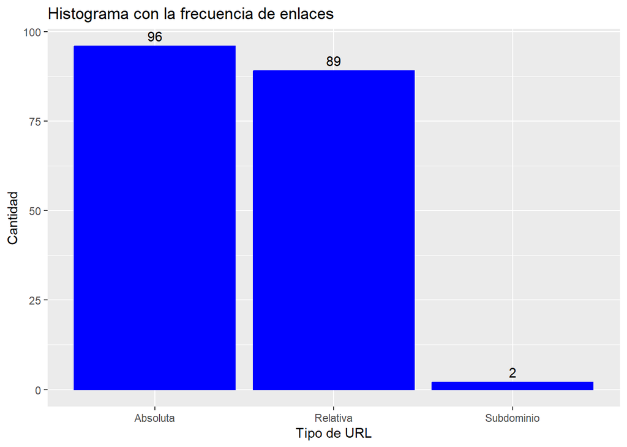

```r
#Se utiliza la función ggplot y geom_bar para mostrar un histograma de valores discretos
ggplot(df,aes(x=tipo_url))+geom_bar(width=0.9, fill=color_graficos, color=color_graficos) + labs (title = "Histograma con la frecuencia de enlaces", x = "Tipo de URL", y="Cantidad") + geom_text(stat = "count", aes(label=after_stat(count)),vjust=-0.5)
```

### 2. Dominios mediawiki

Gráfico de barras que indica la suma de enlaces que apuntan a otros dominios o servicios (distinto a https://www.mediawiki.org) vs. la suma de otros enlaces.

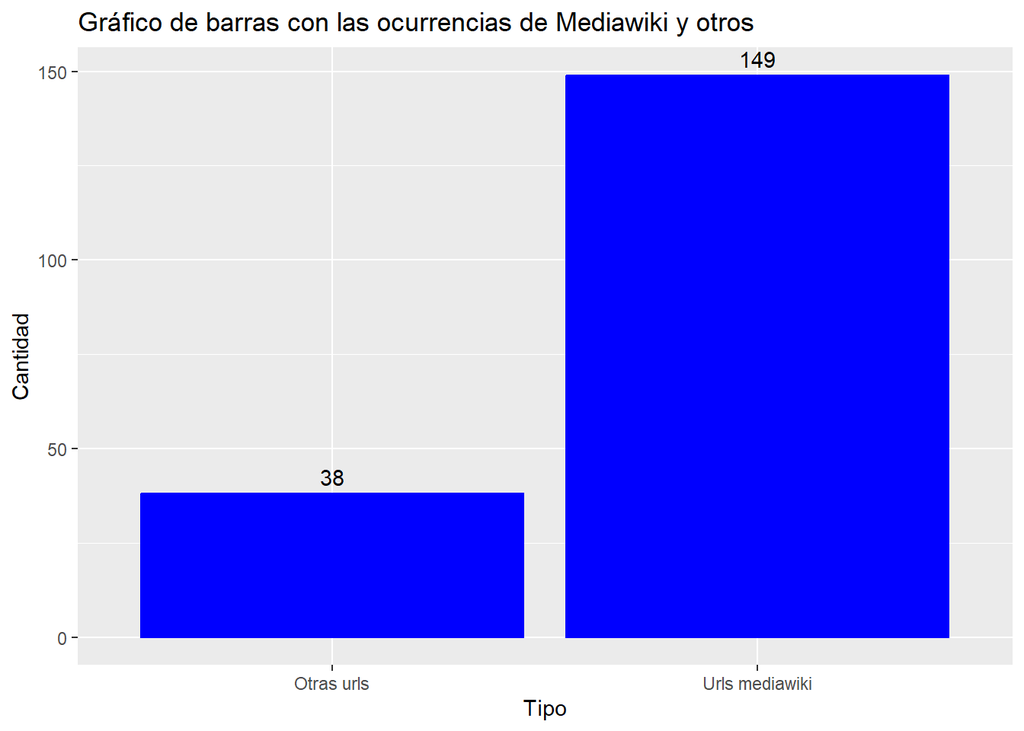

```r
#Se calculan las ocurrencias de urls a mediawiki y a otras urls
v_urls2 <- data.frame(
  categoria = c("Urls mediawiki", "Otras urls"),
  valor = c(length(which(grepl("https://www.mediawiki.org", df$url_absoluta,fixed=FALSE))),length(which(!grepl("https://www.mediawiki.org", df$url_absoluta, fixed=FALSE))))
)

#Se utiliza la función geom_col para mostrar el gráfico de barras
ggplot(v_urls2, aes(x = categoria, y = valor))+geom_col(width=0.9, fill=color_graficos, color=color_graficos) + labs (title = "Gráfico de barras con las ocurrencias de Mediawiki y otros", x = "Tipo", y="Cantidad") + geom_text(aes(label=valor),vjust=-0.5)
```

### 3. Porcentajes de status

Gráfico de tarta indicando los porcentajes de Status del análisis.

```r
#Se calculan los porcentajes según el estado
total_estados <- length(df$estado)
df_estados <- as.data.frame(table(df$estado))
colnames(df_estados) <- c("Estado", "Contador")
df_estados$Porcentaje <- round(df_estados$Contador/total_estados*100,2)

#df_estados$Colores <- rainbow(length(unique(df$estado)))


print(df_estados)
```

```
##   Estado Contador Porcentaje
## 1    200      186      99.47
## 2    404        1       0.53
```

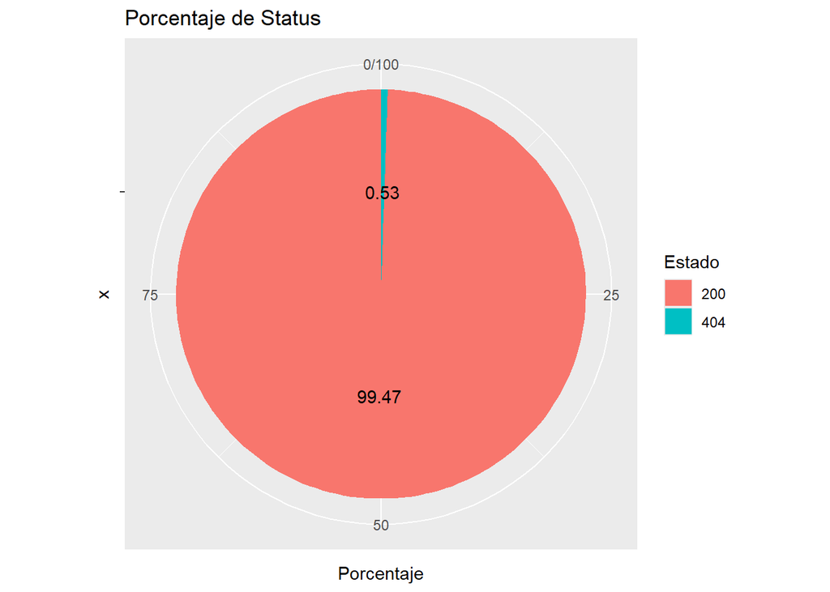

```r
# Se muestra el pie chart con ggplot2
ggplot(df_estados, aes(x = "", y = Porcentaje, fill = Estado)) +
  geom_bar(stat = "identity", width = 0.9) +
  coord_polar(theta = "y") +
  labs(title = "Porcentaje de Status", fill = "Estado") + geom_text(aes(label=Porcentaje), position = position_stack(vjust = 0.5))
```